# Access scATAC-pro results in R

## Introduction

scATAC-pro generates results in plain texts, tables and .rds objects. Here I will go though module by module (most downstream analsis moduels), and illustrate the way to access the scATAC-pro outputs in R using the PBMC 10x Genomics data as used in the manuscript, except in the integrate module, output from another study was used.

## Access results module by module

### Set up some parameters and output directory

```r
PEAK_CALLER = 'COMBINED'
CELL_CALLER = 'FILTER'
output_dir = '/mnt/isilon/tan_lab/yuw1/run_scATAC-pro/PBMC10k/output/'
down_dir = paste0(output_dir, 'downstream_analysis/', PEAK_CALLER, '/',
                  CELL_CALLER, '/')
```

### Access filtered peak-by-cell count matrix

```r
library(data.table)
library(magrittr)
library(ggplot2)
library(Seurat)

read_mtx_scATACpro <- function(mtx_path){
  #mtx_path <- paste0(dirt, "matrix.mtx")
  mtx.dir = dirname(mtx_path)
  feature_path <- paste0(mtx.dir, "/features.txt")
  barcode_path <- paste0(mtx.dir, "/barcodes.txt")


  features <- fread(feature_path, header = F)
  barcodes <- fread(barcode_path, header = F)

  mtx <-  Matrix::readMM(mtx_path) %>%
    magrittr::set_rownames(features$V1)%>%
    magrittr::set_colnames(barcodes$V1)

  return(mtx)
}

mtx_path = paste0(output_dir, 'filtered_matrix/', PEAK_CALLER, '/', CELL_CALLER, '/matrix.mtx')
mtx = read_mtx_scATACpro(mtx_path)
rownames(mtx)[1:10]
```

```
##  [1] "chr1-100028750-100029265" "chr1-100037792-100039050"
##  [3] "chr1-100046917-100047167" "chr1-100047455-100047597"
##  [5] "chr1-100064941-100065019" "chr1-1000654-1000992"
##  [7] "chr1-100065422-100065540" "chr1-100132556-100133436"
##  [9] "chr1-100152259-100152542" "chr1-100184588-100184845"
```

```r
colnames(mtx)[1:10]
```

```
##  [1] "AAACGAAAGACACGGT" "AAACGAAAGAGGTGGG" "AAACGAAAGCACGTAG" "AAACGAAAGCGCCTAC"
##  [5] "AAACGAAAGCTTTCCC" "AAACGAAAGGCGTCCT" "AAACGAAAGGCTTTAC" "AAACGAAAGTGATATG"
##  [9] "AAACGAACAAACGACG" "AAACGAACAATTGCCA"
```

### Clustering

Clustering result was saved in .rds file as *seurat_obj.rds* and clustering label as one of the metadata

```r
seurat_obj = readRDS(paste0(down_dir, 'seurat_obj.rds'))

## cluster label was saved in metadata active_clusters
table(seurat_obj$active_clusters)
```

```
##
##    0    1    2    3    4    5    6    7    8    9
## 2139 1877  823  622  395  362  251  146  129   39
```

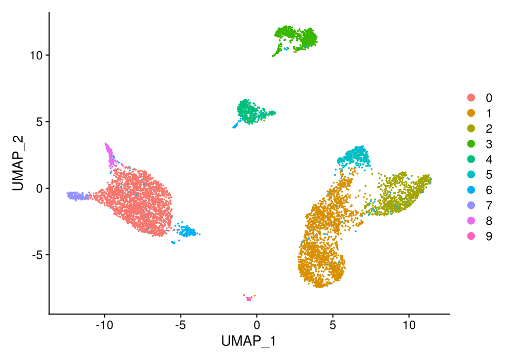

```r
## plot umap
DimPlot(seurat_obj, reduction = 'umap')
```

### GO Analysis

The GO term enrichment result was saved in a .xlsx file.

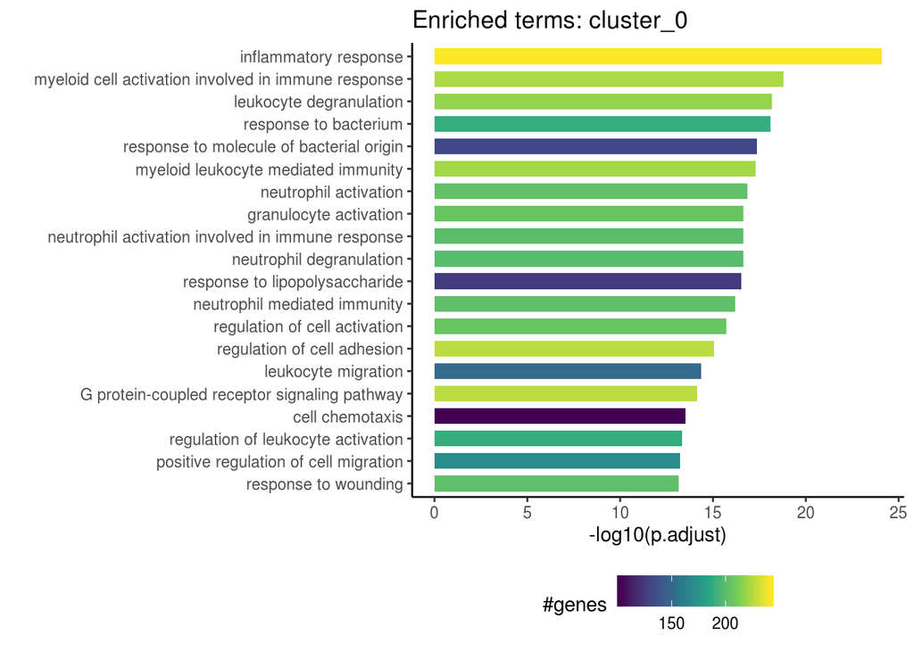

```r
library(xlsx)
group1 = 'one'
group2 = 'rest'
go_file = paste0(down_dir, 'enrichedGO_differential_accessible_features_', group1, '_vs_', group2, '.xlsx')

# get enriched terms for cluster0 for example and show top 20 terms
go_res = xlsx::read.xlsx(go_file, sheetName = 'cluster0')

go_res = data.table(go_res)
go_res[, 'score' := -log10(p.adjust)]
go_res = go_res[order(-score), ]
ngo = min(20, nrow(go_res))
go_res = go_res[1:ngo, ]
go_res = go_res[order(score), ]
go_res$Description = factor(go_res$Description, levels = go_res$Description)

p_go <- ggplot(go_res, aes(y = score, x = Description, fill = Count)) +
  geom_bar(width = 0.7, stat = 'identity') +
  ggtitle("Enriched terms: cluster_0") + theme_classic() +
  theme(legend.position = 'bottom', legend.direction = "horizontal") +
  coord_flip()  +  scale_fill_continuous(name = "#genes", type = "viridis") +
  xlab('') + ylab('-log10(p.adjust)')

p_go
```

### TF motif enrichment analysis

The analysis was done through *chromVAR* R package. A chromVAR object was saved in .rds format (by which users can access the deviation score and the z score per cell) along with a table for enriched TFs per cluster

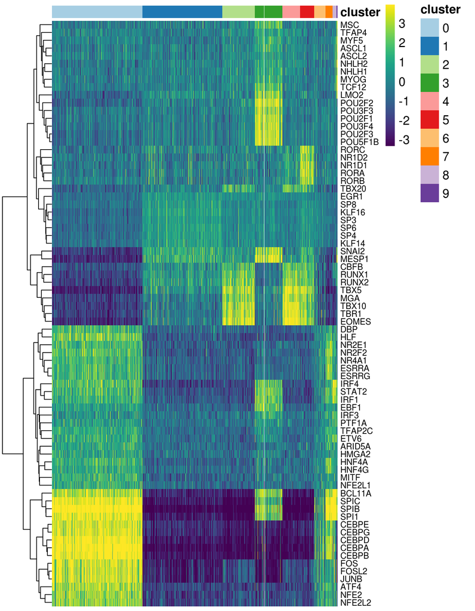

```r
library(chromVAR)
library(BiocParallel)
library(RColorBrewer)
library(viridis)
library(pheatmap)
GENOME_NAME = 'hg38'

# Do differential enrichement analysis with one cluster vs the rest clusters
# clusters are the data frame with columns <barcode> <cluster>
do_DA_motif <- function(mtx_score, clusters, test = 'wilcox',
                  only.pos = T, fdr = 0.05, topn = 10){
  clusters$cluster = as.character(clusters$cluster)
  cls = unique(clusters$cluster)
  res = NULL
  features = rownames(mtx_score)
  for(cluster0 in cls){
    bc0 = clusters[cluster == cluster0]$barcode
    mtx1 = mtx_score[, colnames(mtx_score) %in% bc0]
    mtx2 = mtx_score[, !colnames(mtx_score) %in% bc0]
    mu1 = sapply(1:length(features), function(x) mean(mtx1[x, ]))
    mu2 = sapply(1:length(features), function(x) mean(mtx2[x, ]))

    pvs = rep(0.5, length(features))

    for(x in 1:length(features)){
      a1 = mtx1[x, ]
      a2 = mtx2[x, ]
      if(length(which(!is.na(a1))) < 2 || length(which(!is.na(a2))) < 2) next
      pvs[x] = wilcox.test(a1, a2, alternative = 'greater')$p.value
    }

    pvs.adj = p.adjust(pvs, method = 'fdr')
    res0 = data.table('feature' = features, 'cluster' = cluster0,
                      'mean1' = mu1, 'mean2' = mu2,
                       'pv' = pvs, 'pv_adjust' = pvs.adj)


    res0 = res0[order(pv_adjust), ]
    res0 = res0[pv_adjust <= fdr]

    if(nrow(res0) > topn) res0 = res0[1:topn, ]
    res = rbind(res, res0)
  }
  return(res)
}


metaData = seurat_obj@meta.data

chromVar.obj = readRDS(paste0(down_dir, '/chromVar_obj.rds'))
diff_tf_enrich_file = paste0(down_dir, '/differential_TF_motif_enriched_in_clusters.txt')

if(!file.exists(diff_tf_enrich_file)){
  dev = deviations(chromVar.obj)
  da.res = do_DA_motif(dev,
                       clusters = data.table('barcode' = rownames(metaData),
                                             'cluster' = metaData$active_clusters),
                       topn = 10)
  rm(dev)
}else{
  da.res = fread( paste0(down_dir, '/differential_TF_motif_enriched_in_clusters.txt'))
}

## plot enriched TFs in heatmap
sele.tfs = da.res$feature
zscores = deviationScores(chromVar.obj)
sele.zscores = zscores[sele.tfs, ]


## change tf name to be more readable
if(grepl(GENOME_NAME, pattern = 'hg', ignore.case = T)){
  rnames = rownames(sele.zscores)
  nnames = sapply(rnames, function(x) unlist(strsplit(x, '_'))[3])
  nnames1 = sapply(rnames, function(x) unlist(strsplit(x, '_'))[1])
  rownames(sele.zscores) = ifelse(grepl(nnames, pattern = 'LINE'), nnames1, nnames)
}else{
  rnames = rownames(sele.zscores)
  nnames = sapply(rnames, function(x) unlist(strsplit(x, '_'))[3])
  rownames(sele.zscores) = nnames
  sele.zscores = sele.zscores[!grepl(nnames, pattern = '^LINE'), ]
}


metaData$active_clusters = as.character(metaData$active_clusters)
metaData = data.table(metaData, keep.rownames = T)
setkey(metaData, active_clusters)

rr = metaData$rn[metaData$rn %in% colnames(sele.zscores)]
sele.zscores = sele.zscores[, rr]


sele.zscores = sele.zscores[!duplicated(sele.zscores), ]

ann_col = data.frame('cluster' = metaData$active_clusters)
rownames(ann_col) = metaData$rn

up_cut = quantile(sele.zscores, 0.95, na.rm = T)
low_cut = quantile(sele.zscores, 0.05, na.rm = T)
sele.zscores[is.na(sele.zscores)] = 0
low_cut = min(0, low_cut)
sele.zscores[sele.zscores > up_cut] = up_cut
sele.zscores[sele.zscores < low_cut] = low_cut

cluster = brewer.pal(n=length(unique(metaData$active_clusters)), name = 'Paired')
names(cluster) = sort(unique(metaData$active_clusters))
ann_colors = list('cluster' = cluster)

# resample to reduce memory used
set.seed(2019)
rids = sort(sample(1:ncol(sele.zscores), floor(ncol(sele.zscores)/6)))
ann_col0 = data.frame(ann_col[rids, ])
rownames(ann_col0) = colnames(sele.zscores)[rids]
mtx0 = sele.zscores[, rids]
names(ann_col0) = 'cluster'
pheatmap::pheatmap(mtx0, cluster_cols = F,
                         cluster_rows = T, show_colnames = F, fontsize = 13,
                         annotation_col = ann_col0, color = viridis(100),
                         annotation_colors = ann_colors, fontsize_row = 9)
```

### TF footprinting analysis

The differential bound TFs were saved in a table of plain text format

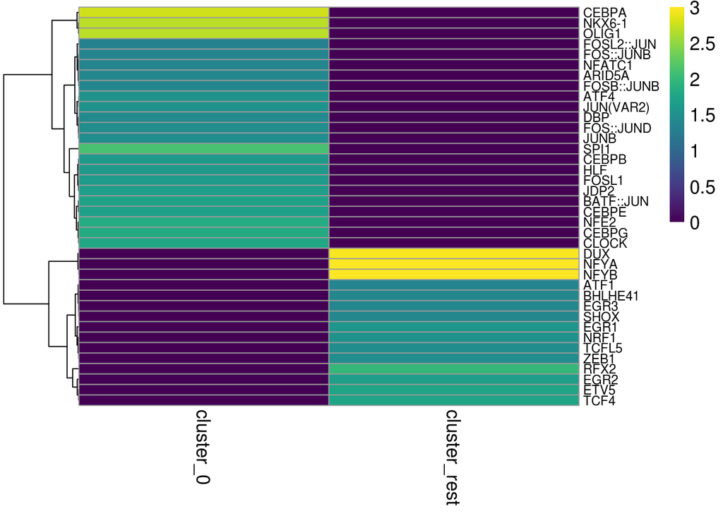

```r
group1_fp = '0'
group2_fp = 'rest'
footprint_stats.file = paste0(down_dir, '/differential_TF_footprint_',
                              group1_fp, '_vs_', group2_fp, '.txt')
if(file.exists(footprint_stats.file)){

  footprint_out = fread(footprint_stats.file)
  if(length(unique(footprint_out$motif)) > 100){
  footprint_out[, 'N' := .N, by = higher_in_cluster]
  cls = unique(footprint_out[N > 10]$higher_in_cluster)
  if(length(cls) >= 1){
    res0 = NULL
    for(cl0 in cls){
      tmp = footprint_out[higher_in_cluster == cl0]
      tmp = tmp[order(P_values)][1:10, ]
      res0 = rbind(res0, tmp)
    }
    footprint_out = rbind(footprint_out[N < 10], res0)
  }
}

  mm = reshape2::acast(motif ~ higher_in_cluster, data = footprint_out,
                       value.var = "P_values")
  mm = -log10(mm)
  mm[is.na(mm)] = 0
  cn = colnames(mm)
  cn.new = sapply(cn, function(x) gsub('_higher', '', x))
  colnames(mm) = cn.new
  mm[mm > 3] = 3
  pheatmap(mm, cluster_cols = F, fontsize = 13, fontsize_row = 9,
                           color = viridis::viridis(100))



}
```

### Access cicero Cis interactions

The cis-interactions were saved in a plain text file. Here we gonna read the interactions and plot the cis-loop within an interested region. You can change parameter *Cicero_Plot_Region* below to your interested genomic region:

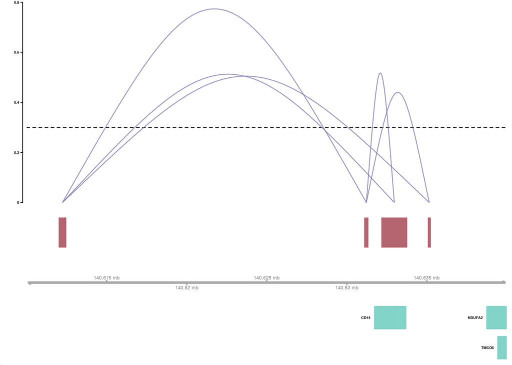

```r
library(cicero)
cicero_conn.file = paste0(down_dir, '/cicero_interactions.txt')
Cicero_Plot_Region = 'chr5:140610000-140640000'
if(file.exists(cicero_conn.file)){
  conns = fread(cicero_conn.file)
  conns = data.frame(conns)
  temp <- tempfile()
  if(grepl(GENOME_NAME, pattern = 'mm10', ignore.case = T)) {
    download.file('ftp://ftp.ensembl.org/pub/release-95/gtf/mus_musculus/Mus_musculus.GRCm38.95.gtf.gz', temp)
  }

  if(grepl(GENOME_NAME, pattern = 'mm9', ignore.case = T)) {
    download.file('ftp://ftp.ensembl.org/pub/release-67/gtf/mus_musculus/Mus_musculus.NCBIM37.67.gtf.gz', temp)
  }

  if(grepl(GENOME_NAME, pattern = 'hg38', ignore.case = T)) {
    download.file('ftp://ftp.ensembl.org/pub/release-95/gtf/homo_sapiens/Homo_sapiens.GRCh38.95.gtf.gz', temp)
  }

  if(grepl(GENOME_NAME, pattern = 'hg19', ignore.case = T)) {
    download.file('ftp://ftp.ensembl.org/pub/release-67/gtf/homo_sapiens/Homo_sapiens.GRCh37.67.gtf.gz', temp)
  }

  gene_anno <- rtracklayer::readGFF(temp)
  unlink(temp)

  # rename some columns to match requirements
  gene_anno$chromosome <- paste0("chr", gene_anno$seqid)
  gene_anno$gene <- gene_anno$gene_id
  gene_anno$transcript <- gene_anno$transcript_id
  gene_anno$symbol <- gene_anno$gene_name
  gene_anno = subset(gene_anno, select = c(chromosome, start, end, strand,
                                           transcript, gene, symbol))
  gene_anno = gene_anno[complete.cases(gene_anno), ]

  chr0 = unlist(strsplit(Cicero_Plot_Region, ':'))[1] ## chr5:140610000-140640000
  region0 = unlist(strsplit(Cicero_Plot_Region, ':'))[2]
  start0 = as.integer(unlist(strsplit(region0, '-'))[1])
  end0 = as.integer(unlist(strsplit(region0, '-'))[2])


  cicero::plot_connections(conns, chr0, start0, end0,
                   gene_model = gene_anno,
                   coaccess_cutoff = .3,
                   connection_width = 1,
                   collapseTranscripts = "longest",
                   viewpoint_alpha = 0)

}
```

### Integration

- For this session, an integrated object from the other study was used for illustration purpose
- Suppose we have an integrated .rds object outputted from *integrate* module with parameter Integrate_By set as ‘VFACS’ (other options are ‘seurat’, ‘pool’, or ‘harmony’)

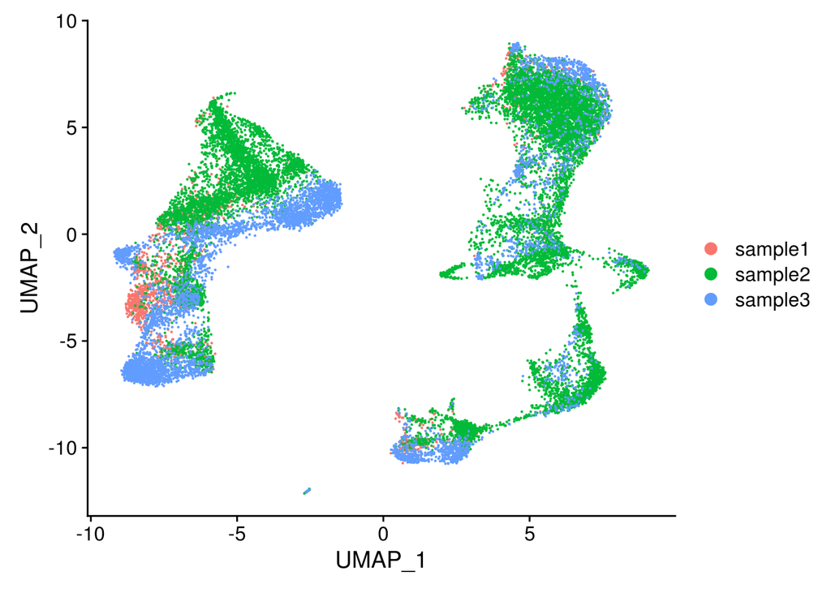

```r
integrated_obj <- readRDS(paste0(output_dir, 'integrated/seurat_obj_VFACS.rds'))

DimPlot(integrated_obj, group.by = 'sample')
```

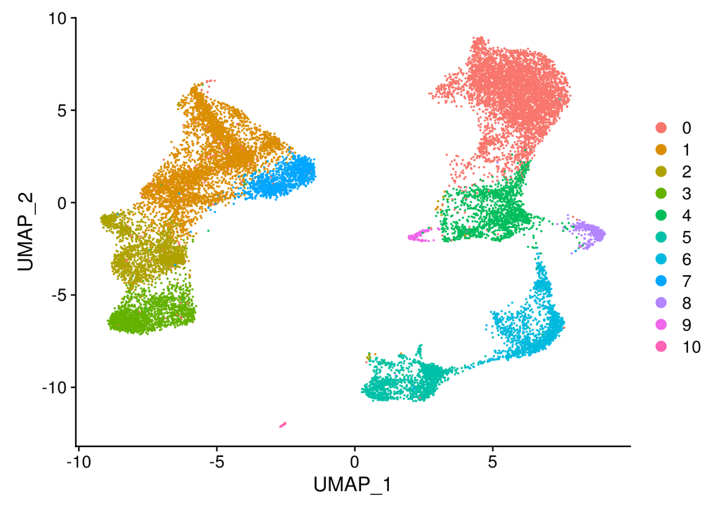

```r
DimPlot(integrated_obj, group.by = 'active_clusters')
```